# On the effect of severe weather events on public health and economy in the US

Luis Sandino

Created on 2016-02-27 06:46:20 using R version 3.2.3 (2015-12-10)

## Synopsis

Storms and other severe weather events can cause both public health and economic problems for communities and municipalities. Many severe events can result in fatalities, injuries, and property damage, and preventing such outcomes to the extent possible is a key concern.

This report involves exploring the U.S. National Oceanic and Atmospheric Administration’s (NOAA) storm database. This database tracks characteristics of major storms and weather events in the United States, including when and where they occur, as well as estimates of any fatalities, injuries, and property damage.

In particular, this report addresses the following questions across the United States:

1. Which types of events are most harmful with respect to population health?
2. Which types of events have the greatest economic consequences?

## Data Processing

List of R libraries loaded:

```r
(.packages())
```

```
##  [1] "ggplot2"   "tidyr"     "dplyr"     "lubridate" "stats"
##  [6] "graphics"  "grDevices" "utils"     "datasets"  "methods"
## [11] "base"
```

Download and read data from the U.S. National Oceanic and Atmospheric Administration’s (NOAA) storm database:

```r
if(!file.exists("storm_data.csv.bz2"))
        {
        file_url <- "https://d396qusza40orc.cloudfront.net/repdata%2Fdata%2FStormData.csv.bz2"
        download.file(file_url,"storm_data.csv.bz2")
        }
dataset <- tbl_df(read.csv(bzfile("storm_data.csv.bz2")))
```

Examine variable names:

```r
names(dataset)
```

```
##  [1] "STATE__"    "BGN_DATE"   "BGN_TIME"   "TIME_ZONE"  "COUNTY"
##  [6] "COUNTYNAME" "STATE"      "EVTYPE"     "BGN_RANGE"  "BGN_AZI"
## [11] "BGN_LOCATI" "END_DATE"   "END_TIME"   "COUNTY_END" "COUNTYENDN"
## [16] "END_RANGE"  "END_AZI"    "END_LOCATI" "LENGTH"     "WIDTH"
## [21] "F"          "MAG"        "FATALITIES" "INJURIES"   "PROPDMG"
## [26] "PROPDMGEXP" "CROPDMG"    "CROPDMGEXP" "WFO"        "STATEOFFIC"
## [31] "ZONENAMES"  "LATITUDE"   "LONGITUDE"  "LATITUDE_E" "LONGITUDE_"
## [36] "REMARKS"    "REFNUM"
```

As can be seen, relevant variables for this analysis are:

> - *EVTYPE*: type of event
> - *FATALITIES*: total number of fatalities related to the event
> - *INJURIES*: total number of injuries related to the event
> - *PROPDMG*: estimated amount of property damage casued by event (in $)
> - *PROPDMGEXP*: multiplier for PROPDMG
> - *CROPDMG*: estimated amount of crop damage casued by event (in $)
> - *CROPDMGEXP*: multiplier for CROPDMG

Extract relevant variables from dataset:

```r
storm_data <- select(dataset,EVTYPE,FATALITIES,INJURIES,PROPDMG,PROPDMGEXP,CROPDMG,CROPDMGEXP)
```

Examine event types:

```r
unique(storm_data$EVTYPE)
```

```
##   [1] TORNADO                        TSTM WIND
##   [3] HAIL                           FREEZING RAIN
##   [5] SNOW                           ICE STORM/FLASH FLOOD
##   [7] SNOW/ICE                       WINTER STORM
##   [9] HURRICANE OPAL/HIGH WINDS      THUNDERSTORM WINDS
##  [11] RECORD COLD                    HURRICANE ERIN
##  [13] HURRICANE OPAL                 HEAVY RAIN
##  [15] LIGHTNING                      THUNDERSTORM WIND
##  [17] DENSE FOG                      RIP CURRENT
##  [19] THUNDERSTORM WINS              FLASH FLOOD
##  [21] FLASH FLOODING                 HIGH WINDS
##  [23] FUNNEL CLOUD                   TORNADO F0
##  [25] THUNDERSTORM WINDS LIGHTNING   THUNDERSTORM WINDS/HAIL
##  [27] HEAT                           WIND
##  [29] LIGHTING                       HEAVY RAINS
```

[output cut: 479 more lines]

As can be seen, there are summary entries that can be dropped from the analysis, as we are interested in individual events only.

Capitalize event names and drop summary entries:

```r
storm_data <- storm_data %>% mutate(EVTYPE = toupper(EVTYPE))
idx <- grep("SUMMARY",storm_data$EVTYPE)
storm_data <- storm_data[-idx,]
```

Group data by event type:

```r
storm_data <- storm_data %>% group_by(EVTYPE)
```

### Damage to public health

Select FATALITIES and INJURIES variables in order to analyze damage to public health. Then, calculate total values per event and arrange data in descending order. Finally, drop events with zero fatalities and zero injuries:

```r
storm_data_health <- storm_data %>%
                     select(EVTYPE,FATALITIES,INJURIES) %>%
                     summarize(TOTAL_FATALITIES = sum(FATALITIES),TOTAL_INJURIES = sum(INJURIES)) %>%
                     arrange(desc(TOTAL_FATALITIES),desc(TOTAL_INJURIES))
storm_data_health <- filter(storm_data_health,TOTAL_FATALITIES>0&TOTAL_INJURIES>0)
head(storm_data_health,10)
```

```
## Source: local data frame [10 x 3]
##
##            EVTYPE TOTAL_FATALITIES TOTAL_INJURIES
##             (chr)            (dbl)          (dbl)
## 1         TORNADO             5633          91346
## 2  EXCESSIVE HEAT             1903           6525
## 3     FLASH FLOOD              978           1777
## 4            HEAT              937           2100
## 5       LIGHTNING              816           5230
## 6       TSTM WIND              504           6957
## 7           FLOOD              470           6789
## 8     RIP CURRENT              368            232
## 9       HIGH WIND              248           1137
## 10      AVALANCHE              224            170
```

### Damage to the economy

```r
storm_data_economy <- storm_data %>%
                      select(EVTYPE,PROPDMG,PROPDMGEXP,CROPDMG,CROPDMGEXP)
storm_data_economy <- filter(storm_data_economy,PROPDMG>0&CROPDMG>0)
```

Examine multipliers variables first:

```r
unique(storm_data_economy$PROPDMGEXP)
```

```
## [1] B M m K 5 0   3
## Levels:  - ? + 0 1 2 3 4 5 6 7 8 B h H K m M
```

```r
unique(storm_data_economy$CROPDMGEXP)
```

```
## [1] M K m k B 0
## Levels:  ? 0 2 B k K m M
```

Create a lookup matrices according to the previous multipliers:

```r
lookup_prop <- data.frame(unique(storm_data_economy$PROPDMGEXP),
                          c(1E+09,1E+06,1E+06,1E+03,1E+05,1,1,1E+03))
names(lookup_prop) <- c("MULT","VALUE")
print(lookup_prop)
```

```
##   MULT      VALUE
## 1    B 1000000000
## 2    M    1000000
## 3    m    1000000
## 4    K       1000
## 5    5     100000
## 6    0          1
## 7               1
## 8    3       1000
```

```r
lookup_crop <- data.frame(unique(storm_data_economy$CROPDMGEXP),
                          c(1E+06,1E+03,1E+06,1E+03,1E+09,1,1))
names(lookup_crop) <- c("MULT","VALUE")
print(lookup_crop)
```

```
##   MULT      VALUE
## 1    M    1000000
## 2    K       1000
## 3    m    1000000
## 4    k       1000
## 5    B 1000000000
## 6    0          1
## 7               1
```

Use lookup matrices to replace multipliers with numeric values:

```r
idx_vect <- match(storm_data_economy$PROPDMGEXP,lookup_prop$MULT)
storm_data_economy$PROPDMGEXP <- lookup_prop$VALUE[idx_vect]
idx_vect <- match(storm_data_economy$CROPDMGEXP,lookup_crop$MULT)
storm_data_economy$CROPDMGEXP <- lookup_crop$VALUE[idx_vect]
```

Calculate total losses per event and arrange data in descending order:

```r
storm_data_economy <- storm_data_economy %>%
                      mutate(PROPDMG = PROPDMG*PROPDMGEXP,CROPDMG = CROPDMG*CROPDMGEXP) %>%
                      summarize(TOTAL_PROPDMG = sum(PROPDMG),TOTAL_CROPDMG = sum(CROPDMG)) %>%
                      arrange(desc(TOTAL_PROPDMG),desc(TOTAL_CROPDMG))
head(storm_data_economy,10)
```

```
## Source: local data frame [10 x 3]
##
##                        EVTYPE TOTAL_PROPDMG TOTAL_CROPDMG
##                         (chr)         (dbl)         (dbl)
## 1                       FLOOD  121971090050    4073443450
## 2           HURRICANE/TYPHOON   26740295000    2607822800
## 3                   HURRICANE    7809278000    2688910000
## 4                 RIVER FLOOD    5079635000    5028734000
## 5                 FLASH FLOOD    2927621132    1382290350
## 6              HURRICANE OPAL    2168000000      19000000
## 7                     TORNADO    1987231053     398706110
## 8                        HAIL    1963393443    1878569103
## 9  TORNADOES, TSTM WIND, HAIL    1600000000       2500000
## 10                   WILDFIRE    1437771000     102923900
```

## Results

### 1. Which types of events are most harmful with respect to population health?

To answer this question, plot the total number of fatalities and injuries per event for the worst 10 in **logaritmic scale**:

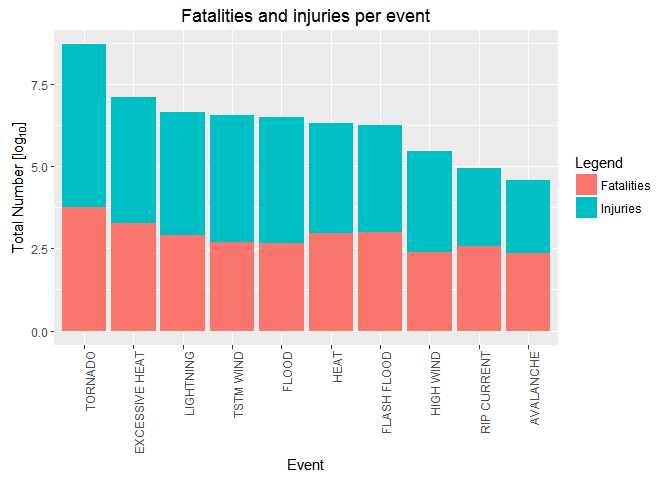

```r
data <- gather(storm_data_health[1:10,],"variable","value",TOTAL_FATALITIES,TOTAL_INJURIES,factor_key = TRUE)
windows()
p <- ggplot(data,aes(x = reorder(EVTYPE,-log10(value)),y = log10(value))) +
     geom_bar(aes(fill = variable),stat = "identity",position = "stack") +
     theme(axis.text.x = element_text(angle = 90, hjust = 1)) +
     labs(title ="Fatalities and injuries per event",
          x = "Event", y = expression('Total Number [log'[10]*']')) +
     scale_fill_discrete(name = "Legend",labels = c("Fatalities", "Injuries"))
print(p)
```

As can be seen in the figure, the type of event which causes more deaths and injuries in the US is a Tornado

### 2. Which types of events have the greatest economic consequences?

To answer this question, plot the total number of property and crop losses per event for the worst 10 in **logaritmic scale**:

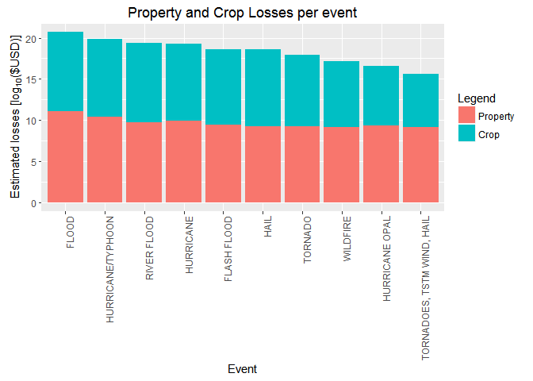

```r
data <- gather(storm_data_economy[1:10,],"variable","value",TOTAL_PROPDMG,TOTAL_CROPDMG,factor_key = TRUE)
windows()
p <- ggplot(data,aes(x = reorder(EVTYPE,-log10(value)),y = log10(value))) +
     geom_bar(aes(fill = variable),stat = "identity",position = "stack") +
     theme(axis.text.x = element_text(angle = 90, hjust = 1)) +
     labs(title ="Property and Crop Losses per event",
          x = "Event", y = expression('Estimated losses [log'[10]*'($USD)]')) +
     scale_fill_discrete(name = "Legend",labels = c("Property", "Crop"))
print(p)
```

As can be seen in the figure, the type of events which cause more economic losses in the US are Floods